# Visualizations and Reporting in R

Kate Aloisio, Smith College Office of Institutional Research

November 19, 2017

## Welcome

- Is R loaded?
- Is RStudio (integrated development environment) loaded?
- Do you have the materials for this workshop on your laptop?

## Visualizations and Reporting in R

Kate Aloisio, Smith College Office of Institutional Research November 19, 2017

## My goals

- Introduction to the language of data visualization in R
- Provide a place to start with a flexible template
- Provide resources

## How does my shop use R?

- Tidying data
- Merging rogue databases
- Annual survey data analysis

## What has been your experience with R?

- Who are you?
- How long have you been using R/RStudio?
- What do you want to get out of this session?

## Materials

- Follow along guide
- Cheatsheets
- Example of a final R Markdown report
- Data
- Slides

## Structure of Workshop

- Data Wrangling
  - Loading Data
  - Manipulating Data
- Visualizations
  - Scatter Plot
  - Line Graph
  - Bar Graph
- Reporting
  - Exporting Images
  - RMarkdown

## Packages

- `tidyverse`
  - `tidyr`
  - `dplyr`
  - `ggplot2`
  - Plus others: http://r4ds.had.co.nz/index.html

## Data

- IPEDS Admissions Survey
- 8 years bound together and cleaned (in R!)
- Side project with Emma Morgan from Tufts

## Import dataset into RStudio

In the Environment tab by clicking on Import Dataset and following the prompts.

## read.csv() - Reading CSV files

```r
ipeds_adm <- read.csv(file.choose(), stringsAsFactors = F, check.names = F)
```

## Let’s explore the data

- `names()`
  - variable names
  - check that all variables were read in
- `str()`
  - structure of your data and variable types
  - check that your variables are the right types (e.g. character, integer, factor)
- `summary()`
  - to see a quick distribution of each variable
  - check for outliers or weirdness

## Data Wrangling - `dplyr`

- `filter()`: keep rows matching criteria
- `select()`: pick columns by name
- `arrange()`: reorder rows
- `mutate()`: add new variables
- `summarise()`: reduce variables to values
- `group_by()`: group data into rows with the same value
  - does not change the underlying data

## `filter()`

- Use filter to just get MA, NY, and NJ public schools.

```r
ds <- filter(ipeds_adm, `State abbreviation_value`%in%c("MA", "NY", "NJ"),
                           `Control of institution`=="Public")
```

- First argument is a data frame
- Subsequent arguments say what to do with data frame
- Always returns a data frame

## Grammar of Graphics

- Plotting Framework
- Leland Wilkinson, Grammar of Graphics 1999
- Based on two principles
  - Graphics are distinct layers
  - Aesthetics are mappings to data

## Grammatical Elements

1. Data
2. Aesthetics
3. Geometries
4. Facets
5. Statistics
6. Coordinates
7. Themes

## Grammatical Elements - Essential

1. **Data**
2. **Aesthetics**
3. **Geometries**
4. Facets
5. Statistics
6. Coordinates
7. Themes

## `ggplot2`

- Hadley Wickham
- Combines layering and aesthetic mapping
- Very flexible

## Grammar of graphics structure

```r
ggplot(data = DATA, mapping = aes(MAPPINGS)) +
  GEOM_FUNCTION(stat = STAT,
                position = POSITION) +
  SCALE_FUNCTION() +
  FACET_FUNCTION() +
  COORDINATE_FUNCTION() +
  THEME_FUNCTION()
```

## Motivation

- Comparison of base graphics with ggplot2, follow along on Guide

## Research Question 1

What is the relationship between admit rate and yield for public institutions in MA, NY, and NJ?

## Plot 1

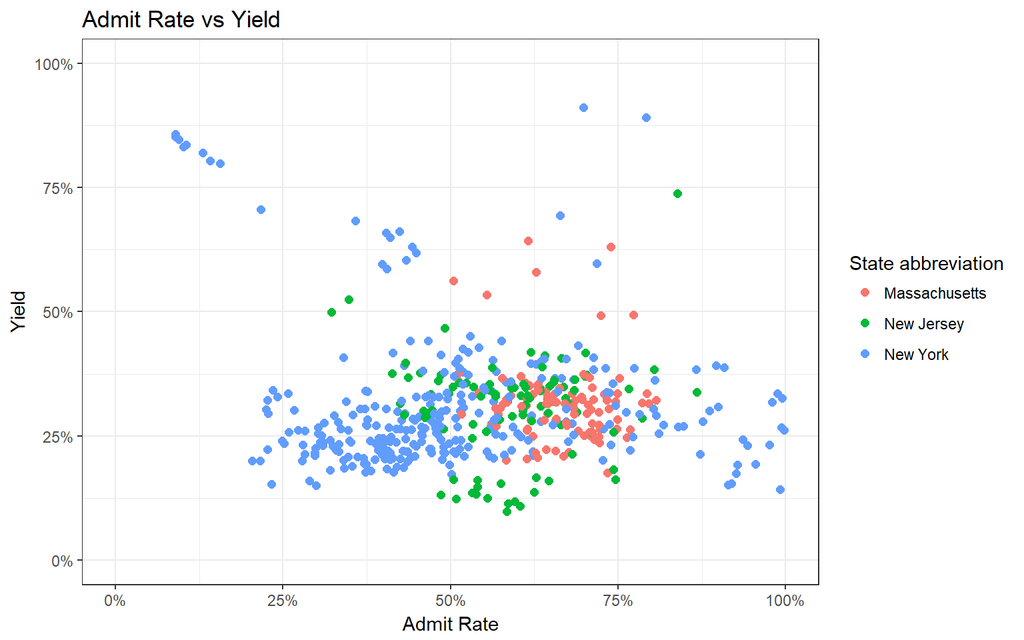

## Let’s Build Plot 1

## Plot 1 - Data

- first need to calculate admit rate and yield

```r
ds1 <- mutate(ds,
              `Admit rate` = `Admissions total`/`Applicants total`,
         `Yield` = `Enrolled total`/`Admissions total`)
```

## Plot 1 - Empty Graph

```r
p1 <- ggplot(ds1)
```

## Plot 1 - Mapping

```r
p1 <- ggplot(ds1,
             aes(x = `Admit rate`,
                 y = `Yield`,
                 color = `State abbreviation`))
```

- defines how variables in dataset are mapped to visual properties
- always paired with the function aes() (i.e. aesthetics)
- `` x = `Admit rate` `` maps admit rate on the x axis
- `` y = `Yield` `` maps yield on the y axis
- `` color = `State abbreviation` `` maps whether the point is in MA, NY, or NJ
- Try it!

## Plot 1 - Geometric Layer

```r
p1 <- ggplot(ds1,
             aes(x = `Admit rate`,
                 y = `Yield`,
                 color = `State abbreviation`)) +
  geom_point(size = 2)
```

- adds a layer of a points to your plot
- many different geoms (check out cheatsheet)

## Plot 1 - Scale Functions

```r
p1 <- p1 +
  scale_x_continuous(name = "Admit Rate",
                     limits = c(0, 1),
                     labels = scales::percent) +
  scale_y_continuous(name = "Yield",
                     limits = c(0, 1),
                     labels = scales::percent))
```

- `limits = c(0, 1)`
  - makes the axis go from 0 to 1
- `labels = scales::percent`
  - turns the axis scale into percents

## Plot 1 - Titles

```r
p1 <- p1 + ggtitle('Admit Rate vs Yield')
```

## Plot 1 - Themes

```r
p1 <- p1 + theme_bw()
```

- personalization!
- Try it!

## Break!

## Research Question 2

Has the average admit rate changed over time for public institutions in MA, NY, or NJ?

## Plot 2

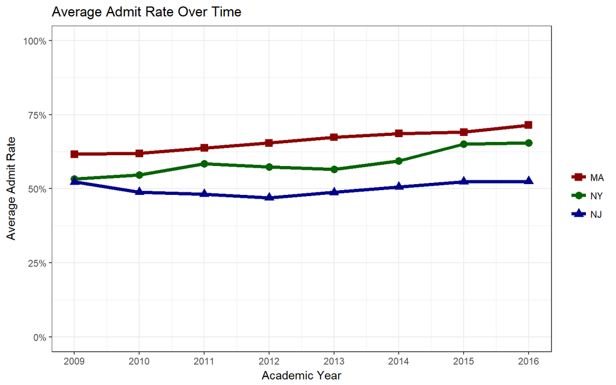

## Let’s create Plot 2

## Plot 2 - Data

```r
ds2 <- ds1 %>%
  group_by(`State abbreviation`,`ACAD_YEAR`) %>%
  summarise(avg_admit = mean(`Admit rate`))
```

- traditional: `z <- function(x, y)`
- pipe: `z <- x %>% function(y)`
- think of it as the word “then”

## `group_by()`

```r
ds2 <- ds1 %>%
  group_by(`State abbreviation`,`ACAD_YEAR`)
```

## `summarise()`

```r
ds2 <- ds1 %>%
  group_by(`State abbreviation`,`ACAD_YEAR`) %>%
  summarise(N = n(), avg_admit = mean(`Admit rate`))
```

- aggregates data into a single summary statistic

## `n()`

```r
ipeds_adm_grouped <- ipeds_adm1 %>%
  group_by(`Sector of institution`,`ACAD_YEAR`) %>%
  summarise(N = n(), avg_admit = mean(`Admit rate`))
```

- counts the number of observations in each group

## `mean()`

```r
ipeds_adm_grouped <- ipeds_adm1 %>%
  group_by(`Sector of institution`,`ACAD_YEAR`) %>%
  summarise(N = n(), avg_admit = mean(`Admit rate`))
```

- calculates the mean for each group

## Tips

- nothing is changing ipeds_adm or more importantly your underlying excel sheet
- you get the group_by variables for free
- it’s good practice to always include N=n()
  - easy way to find duplicates

## Research Question 3

Are public institutions in MA, NY and NJ becoming test optional?

## Plot 3 - Stacked Bar Plot

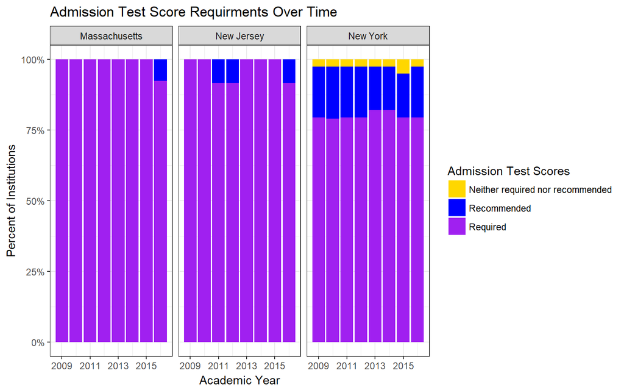

## Plot 3 - Data

```r
ds3 <- ds1 %>% select(UNITID,
                      `Institution (entity) name`,
                      `State abbreviation`,
                      `Admission test scores`,
                      ACAD_YEAR)
```

- only select the variables that we are including
- not necessary but cleaner

## Plot 3 - Stacked Bar Plot

```r
p3 <- ggplot(ds3, aes(x = ACAD_YEAR, fill = `Admission test scores`)) +
  geom_bar(position = "fill") +
  scale_y_continuous(name = "Percent of Institutions",
                     limits = c(0,1),
                     labels = scales::percent) +
  scale_x_continuous(name = "Academic Year",
                     breaks = seq(2009, 2016, by=2)) +
  scale_fill_manual(name = "Admission Test Scores",
                    values = c("gold", "blue", "purple")) +
  facet_grid(.~`State abbreviation`) + # rows~columns
  ggtitle("Admission Test Score Requirments Over Time") +
  theme_bw()

p3
```

## `geom_bar()`

- another geom layer
- new mapping argument `fill`
- the bars will be filled based on the policy category
- Try it!

## Lunch!

## Reporting

- Export Image
- R Markdown

## Exporting Image

- Click on Export in the Plots Pane

## RMarkdown - What is it?

- An HTML file (Not a website)
- Compiled with RMarkdown
- Built in RStudio
- Under the hood is R and html code
- But you don’t have to know any html code

## Let’s create an RMarkdown file

Follow along on guide.

## Made up of:

- Header
- Text
- “Chunks” of R code

## Header

- Title
- Author
- Date
- Output options
  - html_document
  - pdf_document (warning requires LaTeX)
  - rmarkdown::html_vignette

## Text

Anything you can do in word plus html and inline R code.

## R Chunks

- Lines of R code
- Chunk options
  - Should the code be evaluated (`eval`, default is True)
  - Should the code be displayed (`echo`, default is True)
  - Lots more (Purple Cheatsheet)

## Let’s try it!

## More Tips!

- Ask yourself questions.
- Work with frustration.
- Practice!
- And practice consciously: make a prediction, then test it, then reflect.

## Getting Help

- There is extensive documentation and help in R. The `help.start()` function will launch a webpage with links to:
- The R manuals
- The R FAQ
- Search engine
- and many other useful sites
- The `help.search()` function will search the help file for a particular word or phrase. For example: `help.search('cross tabs')`
- The `help()` function or `?functionName` will open the documentation page for a specific function.

## Help Pages Tips

- Scan page for relevant information
- Ignore things that don’t make sense
- Try out examples

## Thank you for coming!

## Common workflow

1. Start New Project
2. Write code in an R script
3. Run code in console with Run
4. Save R script when finished

## Shortcuts

- Up arrow -> Previous command
- Tab -> Auto-complete
- Ctrl (or Cmd) Enter -> Run line from source
- Escape -> To escape from + land
- Ctrl (or Cmd) L -> To clear the console
- Alt - -> To insert the assignment symbol “<-”

## Acknowledgments

- Smith College IR Folks
- Nick Horton and Project MOSAIC
- Jason Bryer Intro to R Slides
- Garrett Grolemund RStudio Intro to R Slides

## Resources

- Student Guide to R using mosaic - http://cran.r-project.org/doc/contrib/Horton+Pruim+Kaplan_MOSAIC-StudentGuide.pdf
- RStudio Support - https://support.rstudio.com/hc/en-us/categories/200035113-Documentation
- More RStudio shortcuts - https://support.rstudio.com/hc/en-us/articles/200711853-Keyboard-Shortcuts
- R-Bloggers http://r-bloggers.com
- R in Action http://www.manning.com/kabacoff/
- R for SAS & SPSS Users http://oit.utk.edu/scc/RforSAS&SPSSusers.pdf
- An Introduction to R http://cran.r-project.org/doc/manuals/R-intro.pdf
- simpleR: Using R for Introductory Statistics http://cran.r-project.org/doc/contrib/Verzani-SimpleR.pdf
- Quick-R http://statmethods.net
- R Reference Card http://cran.r-project.org/doc/contrib/Short-refcard.pdf
- R Cheat Sheets http://devcheatsheet.com/tag/r
- ggplot2 http://had.co.nz/ggplot2
- Tidyverse http://r4ds.had.co.nz/index.html